# Introduction to

### Data objects in R

The data values are stored in data objects. There are 6 types of objects in R Programming. They include vector, list, matrix, array, factor, and data frame. Vectors are one of the basic R programming data objects.

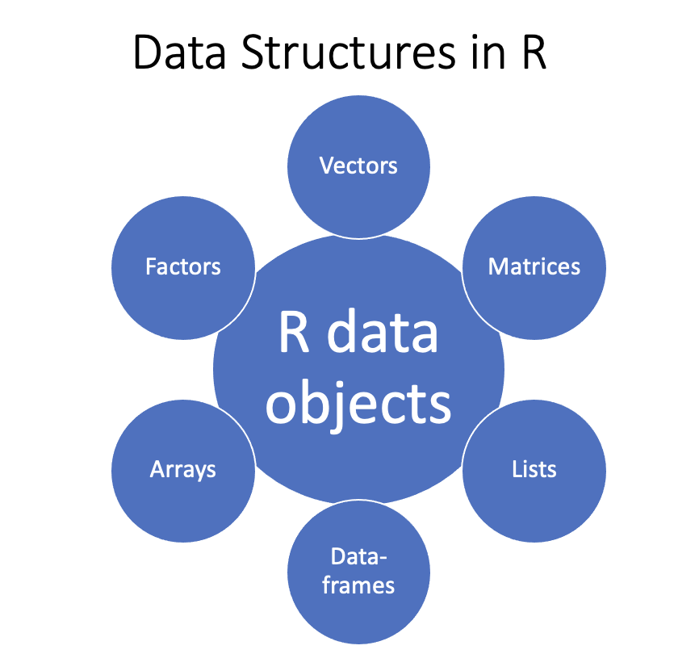

R-objects

1. Vectors
- Vectors are the most basic objects in R
- The c( ) function is used to create vectors of objects
- A vector can only store objects of the same class type data

**Numeric vector**

```r
#  vector has numeric value
vector1 <- c(5, 2.1, 3, 9)
print(class(vector1))
```

```
## [1] "numeric"
```

**Integer vector**

```r
#  vector has numeric value
vector2 = 1:5
print(class(vector2))
```

```
## [1] "integer"
```

**Character vector**

```r
#  vector has character values
vector3 = c("John", "Arkansas", "A", "93.5")
print(class(vector3))
```

```
## [1] "character"
```

**Logical vector**

```r
#  vector has logical values
vector4 = c(FALSE, TRUE, F, T)
print(class(vector4))
```

```
## [1] "logical"
```

**Mixing data in a vector**

When a vector is created with different types of objects (mixing objects), the data type of the objects is implicitly converted or coerced. New vector has all data values have same class.

```r
#  mixing numeric value with integer
vector5 = c(2L, 4.1, 3.5)
print(class(vector5))
```

```
## [1] "numeric"
```

```r
#  mixing numeric value with a character
vector6 = c("A", 4.1, 3.5)
print(class(vector6))
```

```
## [1] "character"
```

```r
#  mixing numeric value with logical value
vector7 = c(TRUE, FALSE,  4.1, 3.5)
print(class(vector7))
```

```
## [1] "numeric"
```

**Typecasting in R**

Typecasting is process of changing the data type of a variable. R Objects can be converted explicitly from one class to another using the “as.” function.

```r
num_vec = c(1.2, 0.5, 2.1, 5.3, 7)
int_vec = as.integer(num_vec)
print(int_vec)
```

```
## [1] 1 0 2 5 7
```

```r
logic_vec = as.logical(int_vec)
print(logic_vec)
```

```
## [1]  TRUE FALSE  TRUE  TRUE  TRUE
```

**Information about vectors**

- three crucial attributes of vectors are: length, class and names
- length( ) function return the number of entries in the vector
- class( ) return type of the vector
- names ( ) return name of the vector if assigned

```r
student_info = c(Name = "John", State = "Arkansas", Grade = "A", Score = 93.5)
names(student_info)
```

```
## [1] "Name"  "State" "Grade" "Score"
```

```r
length(student_info)
```

```
## [1] 4
```

```r
class(student_info)
```

```
## [1] "character"
```

*Note:* If you want to remove the name of a variable, you can type names(vec_name) = NULL.

```r
student_info = c(Name = "John", State = "Arkansas", Grade = "A", Score = 93.5)
names(student_info) = NULL
print(student_info) # no names printed in the result
```

```
## [1] "John"     "Arkansas" "A"        "93.5"
```

*Note:* To assign name of a variable, you can type names(vec_name) = c(name vector that you required) as follows .

```r
names(student_info) = c('Name', 'State', "Grade", 'Score')
print(student_info) # names printed in the result
```

```
##       Name      State      Grade      Score
##     "John" "Arkansas"        "A"     "93.5"
```

2. Matrices
- Matrices are two dimensional array of numbers, it is simply a collection of numerical vectors
- Matrices in R can be created using the matrix( ) function
- matrix function has arguments matrix(data, nrow, ncol, byrow, dimnames)
- data: vector that inputs to construct a matrix
- nrow: number of rows of the matrix
- ncol: number of columns of the matrix
- byrow = TRUE if you want to fill data into matrix by row otherwise byrow = FALSE
- dimnames: Names vector for each dimension enclosed as a list

**Example 1: Empty matrix with 4 rows and 3 columns**

```r
Empty_matrix = matrix(nrow = 4, ncol = 3)
print(Empty_matrix)
```

```
##      [,1] [,2] [,3]
## [1,]   NA   NA   NA
## [2,]   NA   NA   NA
## [3,]   NA   NA   NA
## [4,]   NA   NA   NA
```

```r
data1 = c(2,3,4,2,3,5,3,9,4,2,4,5)
matrix1 = matrix(data = data1, nrow = 4, ncol = 3)
print(matrix1)
```

```
##      [,1] [,2] [,3]
## [1,]    2    3    4
## [2,]    3    5    2
## [3,]    4    3    4
## [4,]    2    9    5
```

*Construct matrix row wise by using the “ byrow = TRUE ”*

```r
dat = 1:12
matrix1 = matrix(data = dat, nrow = 4, ncol = 3, byrow = TRUE)
print(matrix1)
```

```
##      [,1] [,2] [,3]
## [1,]    1    2    3
## [2,]    4    5    6
## [3,]    7    8    9
## [4,]   10   11   12
```

*Matrix can be constructed by assigning the dim to the given vector*

```r
dat = 1:12
dim(dat) = c(3, 4)
print(dat)
```

```
##      [,1] [,2] [,3] [,4]
## [1,]    1    4    7   10
## [2,]    2    5    8   11
## [3,]    3    6    9   12
```

#### Matrix algebra review

- Dimension of matrices

The dimension (or size) of a matrix A is the number of rows follows by the number of columns of A. In R, the dimension of a Matrix A is obtained as dim(A), where the first entry is the number of rows and second entry represents as number of columns.

```r
cars_data = mtcars
dim(cars_data)
```

```
## [1] 32 11
```

- Number of rows and columns can be computed using the functions nrow( ) and ncol( ) respectively.

```r
# number of rows of the car data
nrow(cars_data)
```

```
## [1] 32
```

```r
# number of columns of the car data
ncol(cars_data)
```

```
## [1] 11
```

- Addition/subtraction

Two matrices can be added if and only if they have same dimension, and the sum is the sum the corresponding entries of two matrices.

```r
A = matrix(sample(20), nrow = 4, ncol = 5)
B = matrix(1:20, nrow = 4, ncol = 5)
dim(A) == dim(B)
```

```
## [1] TRUE TRUE
```

```r
print(A+B)
```

```
##      [,1] [,2] [,3] [,4] [,5]
## [1,]   21   11   13   15   18
## [2,]   13   14   28   26   27
## [3,]    6   26   25   32   34
## [4,]    9   21   22   23   36
```

```r
print(A-B)
```

```
##      [,1] [,2] [,3] [,4] [,5]
## [1,]   19    1   -5  -11  -16
## [2,]    9    2    8   -2   -9
## [3,]    0   12    3    2   -4
## [4,]    1    5   -2   -9   -4
```

- Multiply a matrix by a number

Multiplication of a matrix A by a number k is denoted by k A (i.e. each entry of A is multiplied by k), it is computed in R by $k*A$.

```r
A = matrix(sample(6), nrow = 3, ncol = 2)
5*A
```

```
##      [,1] [,2]
## [1,]   20   25
## [2,]   30   15
## [3,]    5   10
```

- Matrix products

1. If A is of size $m\times p$ and B is of size $p\times n$, then the product $AB$ is of size $m\times n$.
2. The matrix product AB in R can be computed using A%*%B.

```r
A = matrix(sample(6), nrow = 3, ncol = 2)
B = matrix(1:8, nrow = 2, ncol = 4)
ncol(A) == nrow(B)
```

```
## [1] TRUE
```

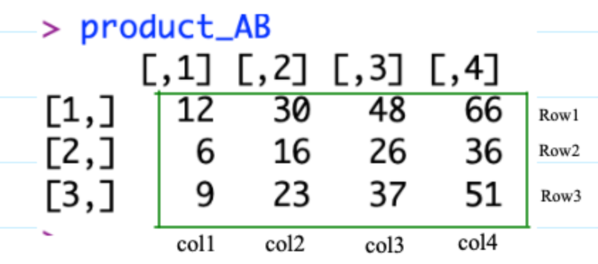

```r
# prosduct matrix AB
product_AB = A %*% B
print(product_AB)
```

**cbind( ) and rbind( ) functions**

We can create matrices by binding columns and rows.

1. rbind( ): Binds vectors to create rows of the matrix
2. cbind( ): Binds vectors to create columns of the matrix

*Example:* There are there plants p1, p2, p3 and they produced two types of products A and B. Plant p1 produced 10 units of A and 7 units of B, plant p2 produced 8 units of A and 9 units of B, and plant p3 produced 6 units of A and 10 units of B. The selling price of A and B per unit are $200 and $180 respectively. What is the the revenue of each plant the company can obtain by selling from these two products?

```r
p1 = c(10, 7)
p2 = c(8, 9)
p3 = c(6, 10)
prod_mat = cbind( p1, p2, p3)
colnames(prod_mat) = cbind("p1", "p2", "p3") #  assign column names
rownames(prod_mat) = c("price A", "price B") #  assign row names
print(prod_mat)
```

```
##         p1 p2 p3
## price A 10  8  6
## price B  7  9 10
```

```r
price = c("price A" = 200, "price B" = 180)
rev = price %*% prod_mat
print(rev)
```

```
##        p1   p2   p3
## [1,] 3260 3220 3000
```

- Elementwise matrix multiplication

Element wise multiplication of two matrices A and B in R can be computed by $A * B$.

```r
A = matrix(sample(6), nrow = 3, ncol = 2)
B = matrix(c(3,5,7, 1, 3, 2), nrow = 3, ncol = 2)
A * B
```

```
##      [,1] [,2]
## [1,]   12    2
## [2,]   15    3
## [3,]   35   12
```

- Transpose of a matrix

A matrix that is obtained by interchanging its rows and columns. For a given matrix A, its transpose is denoted by $A^t$ or $A'$ or $A^T$.

*Note:* The transpose of a matrix in R can be computed by t( )

```r
print(A)
```

```
##      [,1] [,2]
## [1,]    4    2
## [2,]    3    1
## [3,]    5    6
```

```r
Atranspose = t(A)
print(Atranspose)
```

```
##      [,1] [,2] [,3]
## [1,]    4    3    5
## [2,]    2    1    6
```

3. Arrays

Arrays are also the arrangement of vectors similar to matrices.

- Matrices have only rows and columns (two dimensional arrays)
- An array can have more than two dimensions
- Arrays are created using the array( ) function: *array(data, dim, dimnames)*.

```r
array1 <- array(1:24, dim = c(2,4,3) )
print(array1)
```

```
## , , 1
##
##      [,1] [,2] [,3] [,4]
## [1,]    1    3    5    7
## [2,]    2    4    6    8
##
## , , 2
##
##      [,1] [,2] [,3] [,4]
## [1,]    9   11   13   15
## [2,]   10   12   14   16
##
## , , 3
##
##      [,1] [,2] [,3] [,4]
## [1,]   17   19   21   23
## [2,]   18   20   22   24
```

4. Factors

Levels are the unique categorical values of the factor data

```r
# Self assigned factors
response <- factor(c("yes", "yes", "no", "no", "yes", "yes", "yes"))
response
```

```
## [1] yes yes no  no  yes yes yes
## Levels: no yes
```

```r
# creating a factor data with responses with predefined levels
response <- factor(c("agree", "disagree", "agree", "strongly agree", "disagree", "agree"),
                   levels = c("agree", "disagree", "neither agree nor disagree", "strongly agree", "strongly disagree" ))
response
```

```
## [1] agree          disagree       agree          strongly agree disagree
## [6] agree
## 5 Levels: agree disagree neither agree nor disagree ... strongly disagree
```

5. Dataframes

Dataframes are the most commonly used data objects in R for data analysis. Dataframe can take any type of vectors (including numeric, factor, character ) in which the length of every element needs to be the same.

*dataframes can be constructed by using functions data.frame( )*

```r
id <- c('A11', 'B12', 'C13', 'D14')
age <- c(21, 23, 20, 19)
response <- factor(c('yes', 'no', 'no', 'yes'))
df <- data.frame(id,age, response)
print(df)
```

```
##    id age response
## 1 A11  21      yes
## 2 B12  23       no
## 3 C13  20       no
## 4 D14  19      yes
```

6. Lists

List is another type of object in R programming. List can contain heterogeneous data types such as vectors with different length, matrices or another lists.

*A list can be created using the list( ) function.*

```r
lst <- list( "A", 23.5, TRUE, c('John', 'Alex'), matrix(1:4,
nrow = 2, ncol =2))
print(lst)
```

```
## [[1]]
## [1] "A"
##
## [[2]]
## [1] 23.5
##
## [[3]]
## [1] TRUE
##
## [[4]]
## [1] "John" "Alex"
##
## [[5]]
##      [,1] [,2]
## [1,]    1    3
## [2,]    2    4
```

#### Naming the data objects in R

Objects in R can have names for individual elements, rows, and columns and list element.

1. Vector’s name We can assign the name of elements of a vector in two ways:
- by adding value to the names attribute of a vector
- element’s name can also be assigned while creating vector

```r
# assign name for a given unnamed vector of top five states
pop_in_millons <-  c(39.03, 30.03, 22.24 ,19.68, 12.97)
top_five_state <- c("California", "Texas", "Florida", "New York", "Pennsylvania")
names(pop_in_millons) <- top_five_state
print(pop_in_millons)
```

```
##   California        Texas      Florida     New York Pennsylvania
##        39.03        30.03        22.24        19.68        12.97
```

```r
# remove names
names(pop_in_millons) <- NULL
print(pop_in_millons)
```

```
## [1] 39.03 30.03 22.24 19.68 12.97
```

2. Row names and column names of a matrix can be created by using function *rownames( )* and *colnames( )*.

```r
p1 = c(10, 7)
p2 = c(8, 9)
p3 = c(6, 10)
prod_mat = cbind( p1, p2, p3)
print(prod_mat)
```

```
##      p1 p2 p3
## [1,] 10  8  6
## [2,]  7  9 10
```

```r
colnames(prod_mat) = cbind("p1", "p2", "p3") #  assign column names
rownames(prod_mat) = c("price A", "price B") #  assign row names
print(prod_mat)
```

```
##         p1 p2 p3
## price A 10  8  6
## price B  7  9 10
```

3. We can assign the name of list elements

```r
student_info <- list(name = "Alex", ID = '1004392', course = c("Math-4225", "History-4145", "STAT 4101L"), state = "TX")
print(student_info)
```

```
## $name
## [1] "Alex"
##
## $ID
## [1] "1004392"
##
## $course
## [1] "Math-4225"    "History-4145" "STAT 4101L"
##
## $state
## [1] "TX"
```

### Subsetting Data in R

Subsetting is retrieving parts of a data for specific purposes. There are a number of way of extracting subsets of R objects.

```
[ ]: square bracket with desired index
    - returns an object of the same class as original
    - by specifying vector of idices or names, it can be used to select more than one element
[[ ]]: double square bracket
    - returns the list or dataframe elements
$: dolar operator
    - returns the list or dataframe elements by name
    - works as similar as [[]]
```

1. Subset of vectors

```r
vec = c(2, 5, 9, 20, 35, 12, 7)
#print first element of the vector
print(vec[1])
```

```
## [1] 2
```

```r
# select 2nd, 3rd and 7th element
print(vec[c(2, 3, 7)])
```

```
## [1] 5 9 7
```

```r
# print elements > 10
print(vec[vec > 10])
```

```
## [1] 20 35 12
```

2. Subset of Matrices
- A subset of a matrix can be derived by assigning the desired row number(s) and column number(s).
- submat_A = A[‘row position vector’, ‘column position vector’]
- submat_A = A[‘row name vector’, ‘column name vector’]
- A[, ‘column position vector’], all rows selected for the specified columns A[‘row position vector’, ] , all columns selected for the specified rows

```r
A = matrix(1:20, nrow = 5, ncol = 4, byrow = TRUE)
print(A)
```

```
##      [,1] [,2] [,3] [,4]
## [1,]    1    2    3    4
## [2,]    5    6    7    8
## [3,]    9   10   11   12
## [4,]   13   14   15   16
## [5,]   17   18   19   20
```

```r
# print entry of fist row and first column
A11 = A[1, 1]
```

```r
# print sub-matrix with row number 2,3,4 and columns 1,3, 4
sub_mat = A[2:4, c(1,3,4)]
print(sub_mat)
```

```
##      [,1] [,2] [,3]
## [1,]    5    7    8
## [2,]    9   11   12
## [3,]   13   15   16
```

*Using row names and column names*

```r
mtcars = mtcars[1:5, 1:4]
print(head(mtcars))
```

```
##                    mpg cyl disp  hp
## Mazda RX4         21.0   6  160 110
## Mazda RX4 Wag     21.0   6  160 110
## Datsun 710        22.8   4  108  93
## Hornet 4 Drive    21.4   6  258 110
## Hornet Sportabout 18.7   8  360 175
```

```r
sub_mat_mtcars = mtcars[c('Mazda RX4', 'Hornet 4 Drive') , c('mpg', 'hp')]
print(sub_mat_mtcars)
```

```
##                 mpg  hp
## Mazda RX4      21.0 110
## Hornet 4 Drive 21.4 110
```

3. Subset of list objects
- To print data of list element list_name[[‘desired index’ ]] or list_name[[‘element’s name’ ]] or list_name$element_name.
- To print multiple list elements, we can use list_name[‘indices’]

```r
print(student_info)
```

```
## $name
## [1] "Alex"
##
## $ID
## [1] "1004392"
##
## $course
## [1] "Math-4225"    "History-4145" "STAT 4101L"
##
## $state
## [1] "TX"
```

```r
# print data of first list element with position
print(student_info[[1]])
```

```
## [1] "Alex"
```

```r
# print data of first list element with name
print(student_info[["name"]])
```

```
## [1] "Alex"
```

```r
# print data of first list element with name
print(student_info$name)
```

```
## [1] "Alex"
```

```r
# print first two list elements
print(student_info[1:2])
```

```
## $name
## [1] "Alex"
##
## $ID
## [1] "1004392"
```

### Missing values

- Missing values in R are represented by NA
- Undefined mathematical operations, such as division by zero, are represented by NaN (Not a Number)
- is.na( ) and is.nan( ) functions are used to test for NA and NaN respectively
- An NaN value is also an NA, but an NA value is not an NaN value

```r
vec = c(10, 50, NaN, 100, 30, NA, 12)
is.na(vec)
```

```
## [1] FALSE FALSE  TRUE FALSE FALSE  TRUE FALSE
```

```r
vec = c(10, 50, NaN, 100, 30, NA, 12)
is.nan(vec)
```

```
## [1] FALSE FALSE  TRUE FALSE FALSE FALSE FALSE
```

Let’s replace the missing value by the mean of the remaining values.

```r
vec = c(10, 50, NaN, 100, 30, NA, 12)
vec[is.na(vec)] = mean(vec, na.rm = TRUE)
print(vec)
```

```
## [1]  10.0  50.0  40.4 100.0  30.0  40.4  12.0
```